# THERMO NTP

Copyright (c) Dan Kotlyar and CoRE group

# Interface to the Property Table and Data

## Description

Interface into pre-generated **mono**- or **multi-dimensional** property tables.

Provides a very simple look-up table like interface into standard thermophysical tables. Assumes a specific structure of the data stored in a hierarchical data format (HDF) file. Is designated to be used for the purpose of NTP thermal analyses.

# PropertyTable

The following section provides the **inputs, returns, and the methods** of the `PropertyTable` class

### Inputs:

- `h5path` : Full path for the hdf5 file

### Methods:

- `read` : read the property data set of a specific material
- `getref` : obtain the reference for the material database
- `materials`: obtain a list of all the materials in the database

### Raises:

- OSError: If the `h5path` is not valid.

### Example:

```
>>> table = PropertyTable("ThermoPhysicalProperties.h5")
```

### Execute

```python
import os
import sys
sys.path.insert(0, os.path.abspath('..'))
```

```python
from functions.propertytable import PropertyTable
```

```python
# Read the database and store in table
table = PropertyTable("../database/ThermoPhysicalProperties.h5")
```

## The `materials` method

**Obtains all the materials included in the datafile**

This is a useful class if the user is not aware of the materials included in the datafile.

### Returns:

- `list`: all the materials in the database

### Example:

```
>>> table.materials()
```

### Execute

```python
table.materials()
```

```
['H2', 'Molybdenum', 'Tungsten', 'UC', 'UN', 'UO2', 'Zircaloy', 'ZrC']
```

## The `getref` method

**Return the reference for a specific material**

### Inputs:

- `mat` : string, name of the material in the databse, e.g. "H2"

### Returns:

- `str` : description of the reference

### Example:

```
>>> table.getref("H2")
```

### Execute

```python
table.getref("H2")
```

[output not shown]

## The `read` method

**Obtain a complete data set for a specific material.**

### Inputs:

- `mat` : string, name of the material in the databse, e.g. "H2"

### Returns:

- `class` : PropertyData instance

### Raises:

- `KeyError` : If the material `mat` does not exist.
- `TypeError` : If the material `mat` is not a string

### Examples:

```
>>> table = PropertyTable("ThermoPhysicalProperties.h5)
        >>> H2 = table.read("H2")
        >>> UO2 = table.read("UO2")
```

### Execute:

```python
H2 = table.read("H2")
```

# PropertyData

The following section provides the **inputs, returns, and the methods** of the `PropertyData` class

### Inputs:

- `matset` : hdf5 data field

### Methods:

- `evaluate` : obtain a specific property value
- `plot` : plot a property value and the data points from the table
- `whatis` : description of the parameter with its units
- `properties`: obtain a list of all the available properties

### Raises:

If `matset` is not properly defined.

### Example:

```
>>> table = PropertyTable("ThermoPhysicalProperties.h5)
    >>> H2 = table.read("H2")
```

### Execute

```python
import os
import sys
sys.path.insert(0, os.path.abspath('..'))
```

```python
from functions.propertytable import PropertyData
import matplotlib.pyplot as plt
```

```python
H2 = table.read("H2")
```

## The `propertynames` method

**Print all the available properties for a specific material**

### Returns:

`list` with all the properties for the material in the database

### Example:

```
>>> table = PropertyTable("ThermoPhysicalProperties.h5)
        >>> matsetH2 = table.read("H2")
        >>> H2 = PropertyData(matsetH2)
        >>> H2.propertynames()
        [cp', 'cv', 'g', 'h', 'my', 'pr', 'r', 's', 'tc', 'v']
```

### Execute

```python
H2.propertynames()
```

```
['cp', 'cv', 'g', 'h', 'my', 'pr', 'r', 's', 'tc', 'v']
```

## The `whatis` method

**Return information on a specific property**

### Inputs:

`pty` : string, name of the thermal property, e.g. "tc" thermal conductivity

### Returns:

Object with `units` and `name` attributes

### Raises:

- `TypeError` : If the variable `pty` type is not string.
- `KeyError` : If the `pty` does not exist. If the property lacks either the `units` or `description` attributes.

### Example:

```
>>> UO2 = table.read("UO2")
        >>> UO2.whatis("tc")
        Units(name='Thermal Conductivity', units='W/m/K')
        >>> h = UO2.whatis("tc")
        >>> h.name
        'Thermal Conductivity'
        >>> h.units
        'W/m/K'
```

### Execute

```python
H2.whatis("tc")
```

```
Units(name='Thermal Conductivity', units='W/m/K')
```

```python
h = H2.whatis("tc")
print(h.name)
print(h.units)
```

```
Thermal Conductivity
W/m/K
```

## The `evaluate` method

**Evaluate a specific property for given temperature and/or pressure.**

Pressure and/or temperatures can be provided as arguments, or by name. If just the temperature is used, either directly pass a `None` pressure, e.g. `evaluate("tc", None, 600)` or use named arguments with `evaluate("tc", temperature=600)`. Similarly for just pressure, but the option also exists to not pass anything as well, e.g. `evalute("tc", 20)`

### Inputs:

- `pty` : string, name of the thermal property, e.g. "tc" thermal conductivity
- `pressure` : float, optional, pressure in MPa
- `temperature` : float, optional, temperature in Kelvin

### Returns:

`float` : value of the property

### Notes:

- 2-D interpolation is allowed for temperature and pressure.
- 1-D interpolation is allowed only for temperature.

### Raises:

- `KeyError` : Is the property `pty` does not exist in the `matset`.
- `TypeError` : If `pty` is not str type. If `pressure` and/or `temperature` are not properly defined.
- `ValueError` : If `pressure` and/or `temperature` are not properly defined, e.g. values are out of bounds.

### Examples:

```
>>> table = PropertyTable("ThermoPhysicalProperties.h5)
        >>> H2 = table.read("H2")
        >>> H2.evaluate("tc", pressure=8, temperature=600)
        0.3058
        >>> UO2 = table.read("UO2")
        >>> UO2.evaluate("tc", temperature=600)
        5.6532
```

### Execute:

```python
table = PropertyTable("../database/ThermoPhysicalProperties.h5")
H2 = table.read("H2")
```

```python
print(H2.evaluate("tc", pressure=6, temperature=1754))
print(H2.evaluate("cp", pressure=6, temperature=1754))
```

```
0.7120571
16535.7
```

## The `plot` method

**Comparative plot for the value of a specific property.**

### Inputs:

- `pty` : string, name of the thermal property, e.g. "tc" thermal conductivity
- `pressure` : float, optional, pressure in MPa
- `temperature` : float, optional, temperature in Kelvin
- `desc` : str, optional, description of the property. Default value is read through the whatis method.
- `units` : str, optional, description of the property's units. Default value is read through the whatis method.

### Raises:

- `KeyError` : Is the property `pty` does not exist in the `matset`.
- `TypeError` : If `pty` is not str type. If `pressure` and/or `temperature` are not properly defined.
- `ValueError` : If `pressure` and/or `temperature` are not properly defined, e.g. values are out of bounds.

### Examples:

```
>>> table = PropertyTable("ThermoPhysicalProperties.h5)
        >>> H2 = table.read("H2")
        >>> H2.plot(pressure=8, temperature=600)
        >>> H2.plot(pressure=8, temperature=600,
        ...           desc='conductivity', units='W/m/K')
```

### Execute:

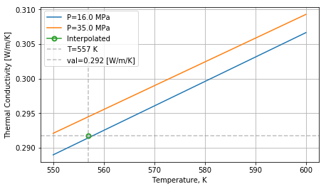

```python
H2.plot("tc", pressure=18, temperature=557)
```

## The `mixbinay` method

**Evaluate a weighted value for a binary mixture.**

The method evaluates the weighted property given two values that represent the same property for two materials given a certain weight fraction at a specific temperature and/or pressure .

#### Methodology: weighted properties for binary systems

There are several options to weight the properties of binary mixtures.  
**1. Serial:**

\begin{align} \begin{split} z = w\times z_1 + (1-w)\times z_2 \end{split} \end{align}

**2. Parallel:**

\begin{align} \begin{split} z = \left( \frac{w}{z_1} + \frac{1-w}{z_2} \right)^{-1} \end{split} \end{align}

where $w$ is the weight fraction for material of type 1 having a property (e.g. conductivity) value of $z_1$. The property value for material 2 is $z_2$.

There is a third option that is used to weight the properties when particles (e.g. UO$_2$) are embedded within a matrix material, such as tungsten.

**3. Bruggeman–Fricke methodology**

\begin{align} \begin{split} z = z_1 + (1-w)(z_2-z_1)\left(\frac{z_1}{z_2} \right)^{1/3} \end{split} \end{align}

where $w$ is the volume fraction for the particles' material having a property value of $z_1$. The property value for the matrix material is $z_2$.

### Inputs:

- `val1` : float, value for material of type 1, e.g. thermal conductivity for Tungsten
- `val2` : float, value for material of type 2, e.g. thermal conductivity for Moly
- `w1` : float, weight fraction of material-1
- `method` : string, weighting method, e.g. "parallel"

### Returns:

value of the weighted property for the mixture, float

### Raises:

- `ValueError` : If any of the `val1`, `val2`, or `w1` are not properly defined, e.g. negative numbers. If the given `method` does not exist.
- `TypeError` : Any of the values, e.g. `val1` is not a float type.

### Notes:

The Bruggeman-Fricke weighting method assumes that `val1` represent the particles, `val2` represent the matrix, and `w1` is the volume fraction of the particles in the matrix.

### Examples:

```
>>> mixbinary(val1= 1.7, val2= 2.5, w1= 0.01, method="Parallel")
    2.488290398126464
    >>> mixbinary(val1= 1.7, val2= 2.5, w1= 0.01, method="Serial")
    2.492
```

### Execute:

```python
from functions.propertytable import mixbinary
```

```python
mixbinary(val1= 0.5, val2= 4.6, w1= 0.164, method= "Parallel")
```

```
1.9617877857386554
```

## Summary example

Obtain the **weighted conductivity** of the UO2 matrix (40% by volume) embedded within a tungsten materix

**Read the data**

```python
data = PropertyTable("../database/ThermoPhysicalProperties.h5")
```

**Read the thermal conductivity for UO2 and Tungsten**

```python
UO2 = data.read("UO2")
Tungsten = data.read("Tungsten")
```

**Obtain the conductivity values for UO2 and Tungsten**

```python
valUO2 = UO2.evaluate("tc", temperature= 1585)
valW = Tungsten.evaluate("tc", temperature= 1585)
```

**Obtain the weighted value**

```python
val = mixbinary(val1= valUO2, val2= valW, w1= 0.4, method= "Bruggeman-Fricke")
```

```python
print("Conductivity for UO2 is {} W/mK".format(round(valUO2, 2)))
print("Conductivity for Tungsten is {} W/mK".format(round(valW, 2)))
print("Weighted conductivity is {} W/mK".format(round(val, 2)))
```

```
Conductivity for UO2 is 1.78 W/mK
Conductivity for Tungsten is 109.14 W/mK
Weighted conductivity is 18.1 W/mK
```

**Plot results**

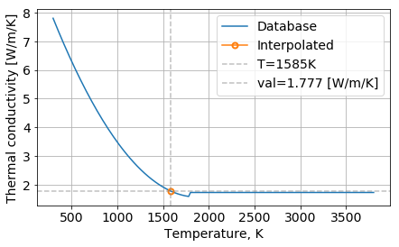

```python
UO2.plot("tc", temperature=1585, desc ='Thermal conductivity', units='W/m/K')
```

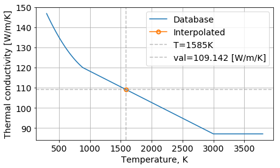

```python
Tungsten.plot("tc", temperature=1585, desc ='Thermal conductivity', units='W/m/K')
```